# Estadística descriptiva y análisis exploratiorio de datos 2021-1 Trabajo grupal 1

Jeison Durango Cc 1214745706 Joelle Rios Cc 1064978739 Daniela Guardia Cuervo Cc 1007675467 Isa Daut Mercado Cc 1193530926

4/14/2021

## Pregunta: ¿quiénes tienen mejor papa por carrera y género?

Se espera que los hombres de Ingeniería de Sistemas tengan un mejor promedio que el resto.

```
##      [,1]  [,2]     [,3]     [,4]     [,5]
## [1,]  4.1 4.375 3.997368 4.009524 4.016667
```

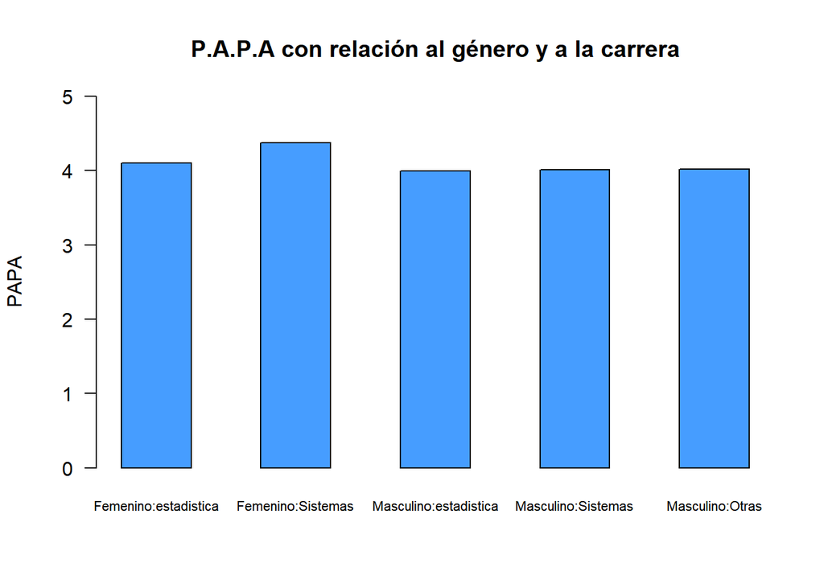

```
##  Femenino:estadistica Femenino:Sistemas Masculino:estadistica
##  Min.   :4.1          Min.   :4.375     Min.   :3.997
##  1st Qu.:4.1          1st Qu.:4.375     1st Qu.:3.997
##  Median :4.1          Median :4.375     Median :3.997
##  Mean   :4.1          Mean   :4.375     Mean   :3.997
##  3rd Qu.:4.1          3rd Qu.:4.375     3rd Qu.:3.997
##  Max.   :4.1          Max.   :4.375     Max.   :3.997
##  Masculino:Sistemas Masculino:Otras
##  Min.   :4.01       Min.   :4.017
##  1st Qu.:4.01       1st Qu.:4.017
##  Median :4.01       Median :4.017
##  Mean   :4.01       Mean   :4.017
##  3rd Qu.:4.01       3rd Qu.:4.017
##  Max.   :4.01       Max.   :4.017
```

En general el promedio del PAPA de las carreras tomadas por género varian muy poco, todos estos promedios están en un valor que tiende a 4.  
La respuesta real a esta pregunta es que en promedio las mujeres que están en la carrera de Ingeniería de Sistemas son las que tienden a tener un mayor PAPA que el resto de generos y carreras

## Pregunta: ¿en qué carrera están las mujeres y hombres con el mayor semestre?

Se espera que las mujeres y hombres de Ingenieria de Sistemas son los que están en los semestres más altos.

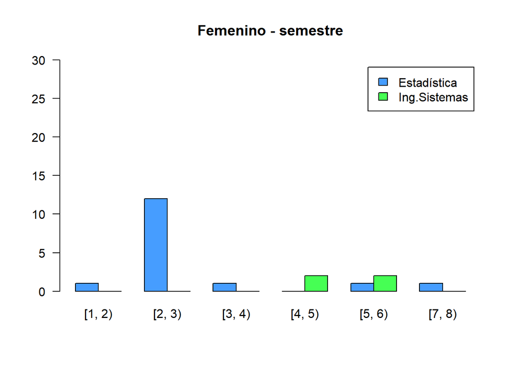

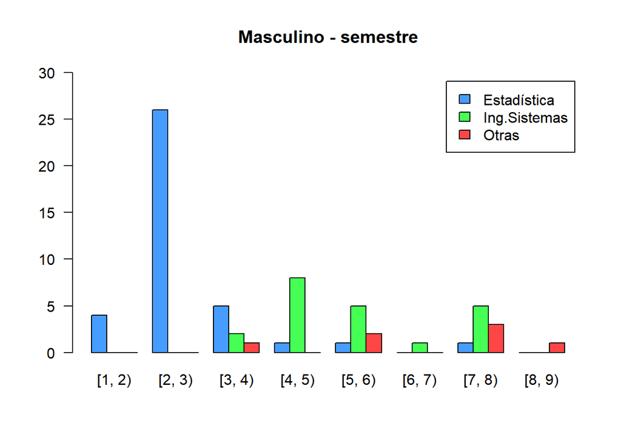

```
## [1] "Cantidad de datos del género femenino: "
```

```
## [1] 20
```

```
## [1] "Cantidad de datos del género masculino"
```

```
## [1] 66
```

```
## [1] "Promedio de los semestres del género femenino: "
```

```
## [1] 3.05
```

```
## [1] "Promedio de los semestres del género masculino: "
```

```
## [1] 3.669697
```

En los semestres más bajos que serían del 1 al 3 hay más concentración de estudiantes de la carrera de Estádistica, por otro lado en los semestres más altos hay más concentración de estudiantes de Ingeniería de Sistemas y otras carreras(Ingeniería Física, Ingeniería Administrativa, Ingeniería Industrial, Matemáticas y Otras).  
La respuesta real a esta pregunta es que con respecto al género masculino los estudiantes de otras carreras aunque en menor frecuencia son los que están en el semetre más alto, seguidos por los estdiantes de Ingeniería de Sistemas y algunos pocos de Estadística.

## Pregunta: ¿En el área Metropolitana qué estrato tiende a creer más en las conspiraciones falsas?

Se espera que las personas de estratos bajos(Estratos 1, 2 y 3) en el área Metropolitana tienden a creer más en conspiraciones

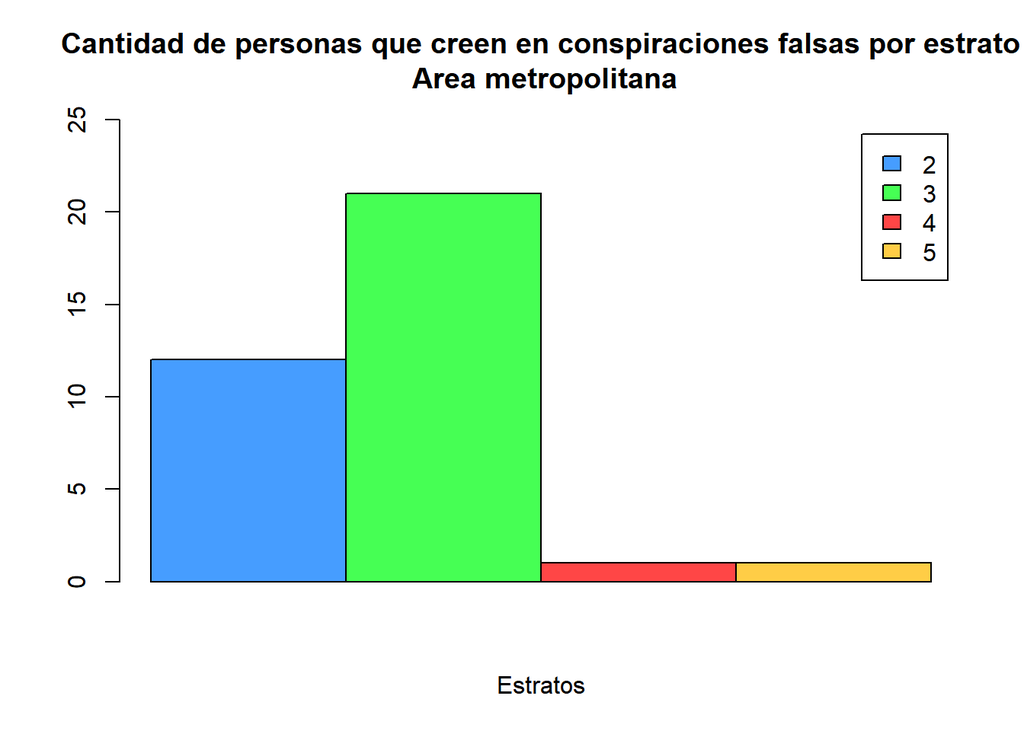

```
##    Min. 1st Qu.  Median    Mean 3rd Qu.    Max.
##   2.000   2.000   3.000   2.743   3.000   5.000
```

```
## [1] "Cantidad de personas que creen en al menos una conspiración falsa:"
```

```
## [1] 35
```

Las personas de estratos altos(Estratos 4, 5 y 6) tienen una muy baja frecuencia en la base de datos representando el 8.3% del total, además de que en la base de datos no hay estduantes de estrato 6. En la base de datos no hay estudiantes de estrato 1 que estén dentro del área Metropolitana, por lo tanto no estran en la gráfica.

La respuesta real a esta pregunta es que efectivamente que las personas de estratos bajos son los que tienden a creer más en conspiraciones falsas.

## Pregunta: ¿Un buen ICFES significa un buen PAPA?

Se espera que las personas tengan un PAPA proporcional a su puntaje de ICFES, es decir, si obtuvieron un alto puntaje en el ICFES, su PAPA debe ser también alto. Para analizar esta hipótesis, se grafica los puntajes del ICFES junto con sus respectivos valores del PAPA, y se espera que se distribuyan al rededor de una línea recta con pendiente 5/500 (máximo PAPA sobre máximo ICFES, línea roja).

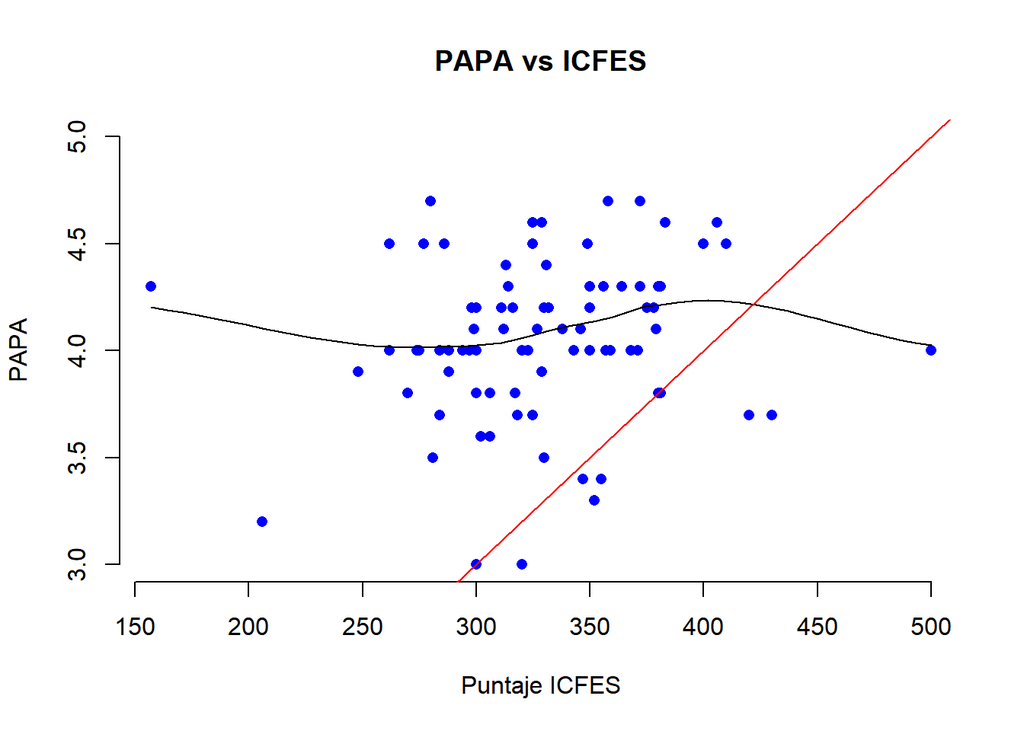

Al hacer el análisis, se nota que los puntos se distribuyen al rededor de la línea negra, por lo tanto se descarta la hipótesis de que un buen ICFES significa un buen PAPA.

## Pregunta: ¿El desempeño de las mujeres en las ICFES es diferente al de los hombres?

Se quizo comparar el desempeño de las mujeres en las ICFES con respecto al de los hombres. Para esto, se muestra el promedio de los puntajes de las ICFES para cada género para cada año en el que se realizaron las pruebas.

Nota: No existen datos sobre el puntaje de las ICFES de las mujeres para antes del 2013, por eso solo se muestran desde el 2013 al 2019.

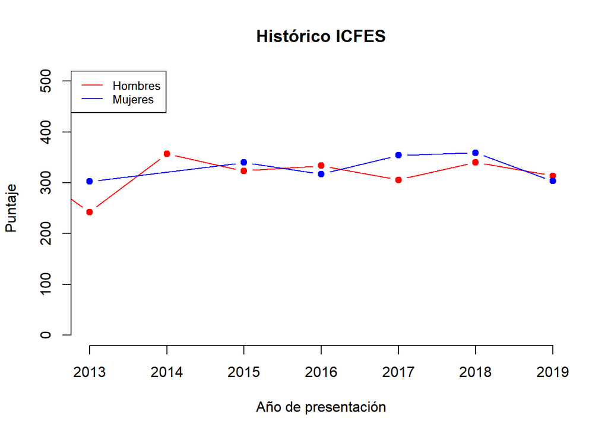

Como se ve en la gráfica, no se nota una diferencia significativa en el puntaje obtenido en las ICFES para cada género.

## Pregunta: ¿Hay alguna diferencia entre las personas que tienen instalado los softwares R y RStudio según su carrera?

Hipótesis 1: Se espera que las personas de estadística que tienen ambos software instalados sean muchas más que las que no, debido a que son programas que suelen usar regularmente. Hipótesis 2: Se espera que el porcentaje de personas de estadística que sí tienen instalados ambos programas sea mucho mayor al de los de ingeniería de sistemas, teniendo en cuenta que los de esta carrera no los usan muy seguido.

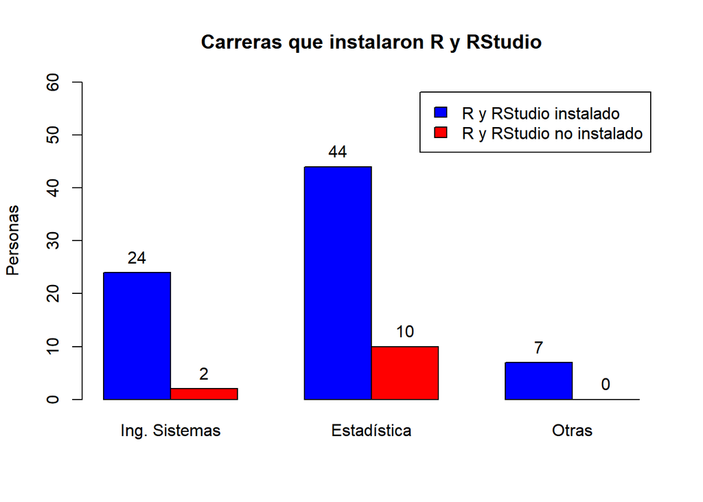

Porcentaje de personas de estadística que tienen ambos programas instalados: 81.48%

Con un porcentaje tan alto, se afirma la hipótesis 1: la mayoría de las personas de estadística tienen ambos programas instalados.

Debido a que el porcentaje de las personas de ingeniería de sistemas es superior al de los de estadística, se rechaza la hipótesis 2.

## Pregunta: ¿Los hombres que creen que los alienígenas visitaron las civilizaciones antiguias son más jóvenes que los que no?

Se espera que los hombres jóvenes crean más en este tipo de conspiraciones a comparación de los hombres de mayor edad.

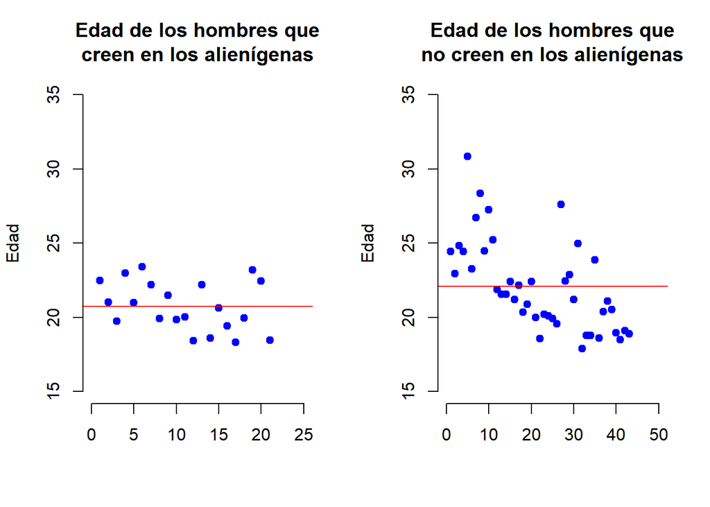

Se observa que el promedio de la edad de los hombres que creen en esta conspiración es de 21, mientras que el de los que no es de 22. Hay una leve diferencia en estos promedios, pero no es suficiente para que la hipótesis sea cierta.

## Pregunta: ¿Las personas que creen que las vacunas son efectivas confían en que sus compañeros tienen mejor desempeño?

Se espera que las personas que creen que las vacunas funcionan, tengan más fe en que sus compañeros sean capaces de responder correctamente preguntas de geometría.

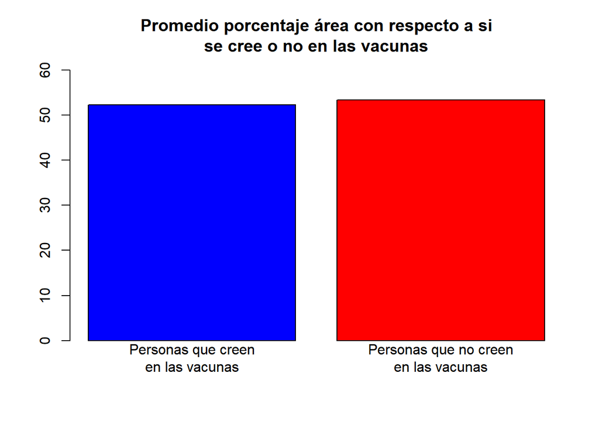

Al analizar los resultados, se observa que no existe diferencia significativa entre los promedios de los porcenjes de acierto con respecto a si las personas creen en las vacunas o no.